# Chapter 2 Exercises

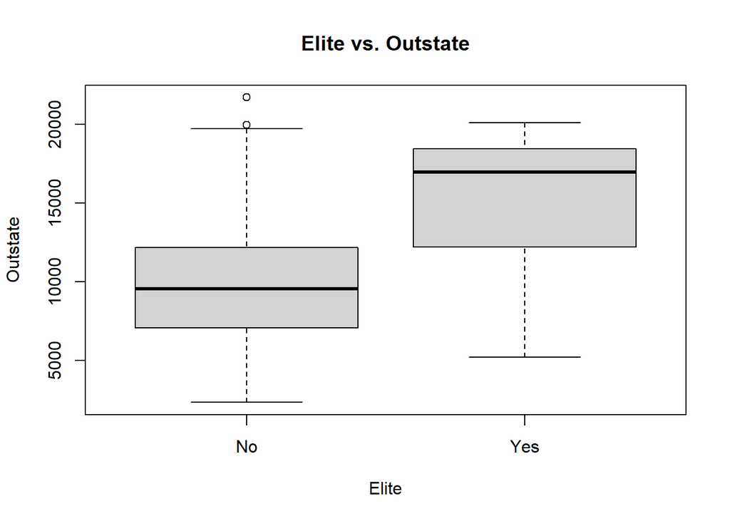

   ```r
   plot( college$Elite, college$Outstate, xlab="Elite", ylab="Outstate", main="Elite vs. Outstate")
   ```

   Elite colleges tend to have more out-of-state students than non-elite colleges.
   22. Use the **hist()** function to produce some histograms with differing numbers of bins for a few of the quantitative variables. You may find the command **par(mfrow=c(2,2))** useful: It will divide the print window into four regions so that four plots can be made simultaneously. Modifying the arguments to this function will divide the screen in other ways.

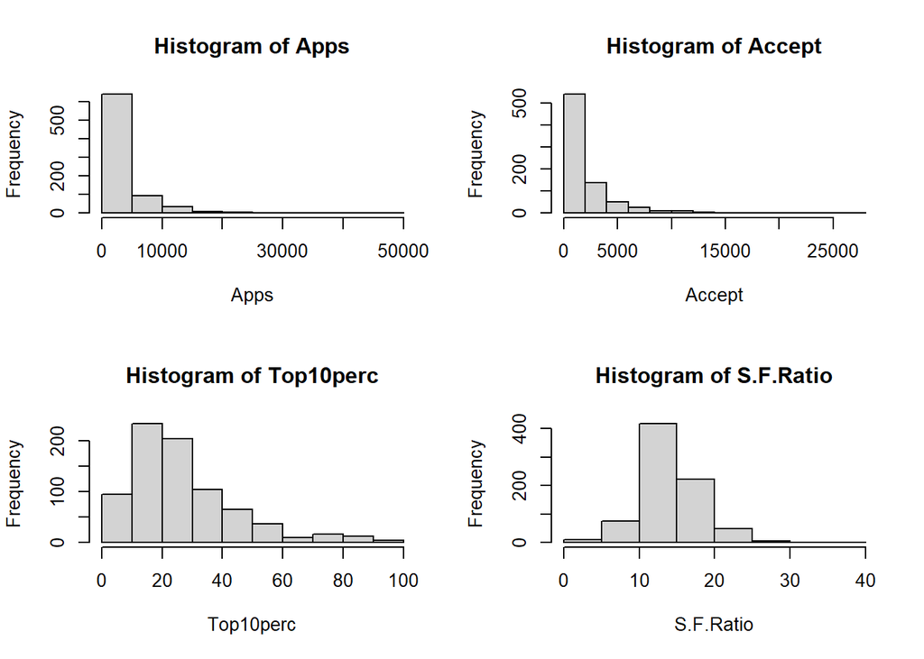

   ```r
   par(mfrow=c(2,2))
   hist(college$Apps, xlab="Apps", main="Histogram of Apps")
   hist(college$Accept, xlab="Accept", main="Histogram of Accept")
   hist(college$Top10perc, xlab="Top10perc", main="Histogram of Top10perc")
   hist(college$S.F.Ratio, xlab="S.F.Ratio", main="Histogram of S.F.Ratio")
   ```

   Many colleges recieve only a few applications (<5000), whereas a few colleges recieve many applications. Many colleges accept only a few students (<2500), whereas a few colleges accept many students. The distributions for **Top10perc** and **S.F.Ratio** are approximately normal, although the former has a heavy upper tail, which may indicate that there are some elite colleges who have much higher numbers of incoming students who graduated in the top 10% of their high school class.

   vi Continue exploring your data, and provide a brief summary of what you discover.

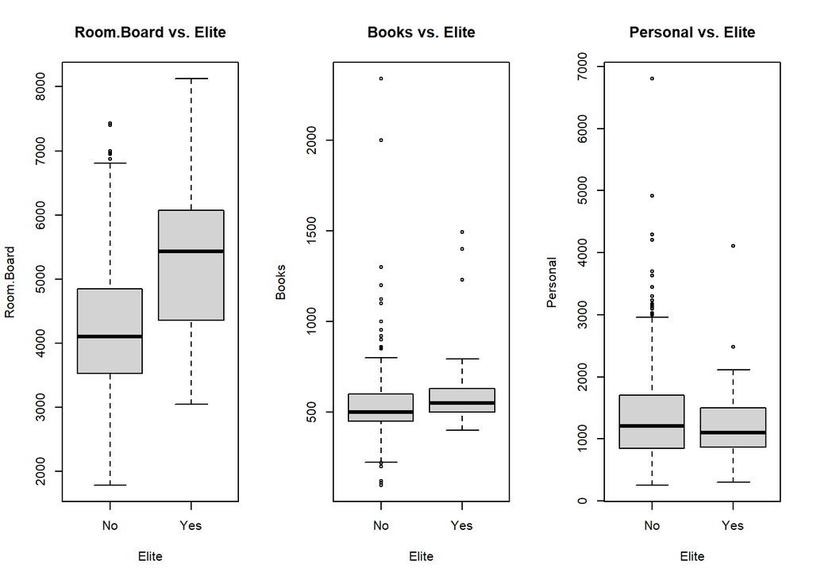

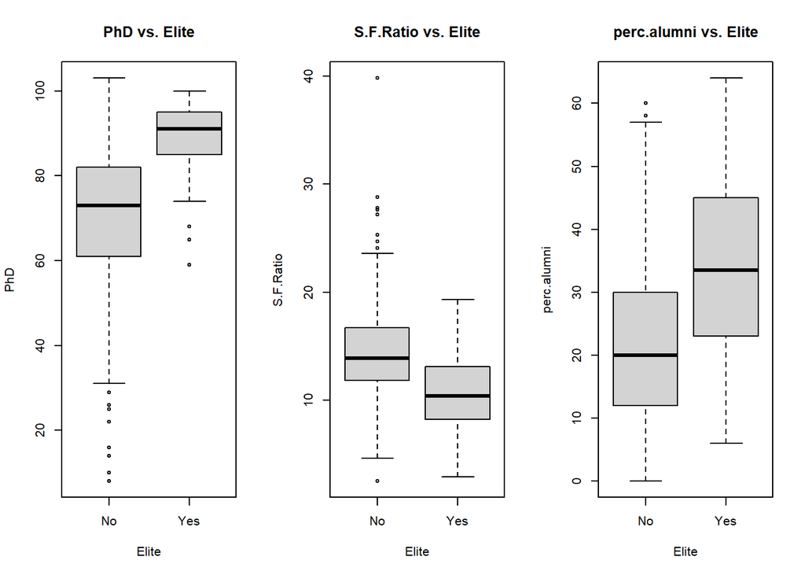

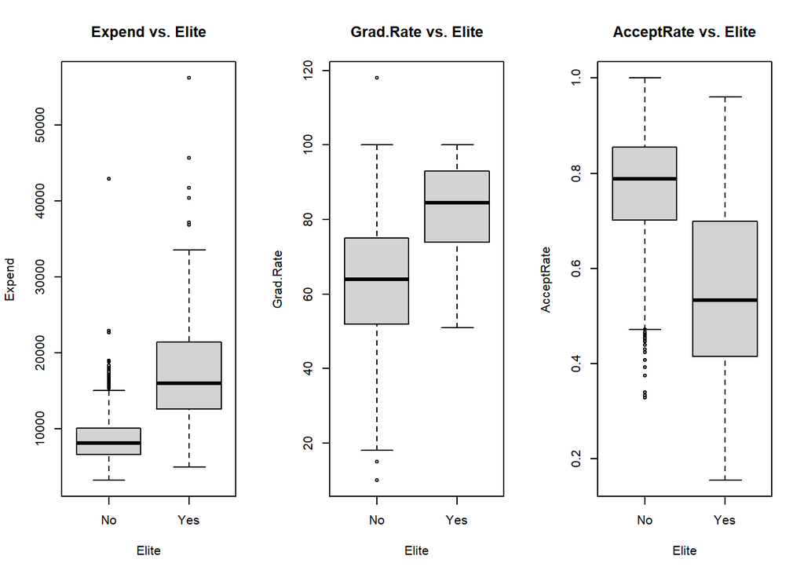

   ```r
   # Okay, let's calculate acceptance rate
   college$AcceptRate = college$Accept/college$Apps
   par(mfrow=c(1,3))
   # And now, I want to look at different variables as a function of elite
   for (i in c(10,11,12,13,15,16,17,18,20)){
     plot(x=college$Elite, y=college[,i], xlab="Elite", ylab=names(college)[i], main=paste(names(college)[i],"vs. Elite"))
   }
   ```

   **Elite** is positively correlated with **Outstate**, **Room.Board**, **PhD**, **perc.alumni**, **Expend**, **Grad.Rate**, and is negatively correlated with **S.F.Ratio** and **AcceptRate**. All of these associations make sense, as generally, you would expect that elite schools are more expensive and attract the best students and faculty. The acceptance rates are lower, which may help to explain why the student-to-faculty ratios are lower for elite schools.

   ```r
   # How many private schools are elite? Public schools?
   sum( college$Private == "Yes" & college$Elite == "Yes")/length(college$Private)*100
   ```

   ```
   ## [1] 8.365508
   ```

   ```r
   sum( college$Private == "No" & college$Elite == "Yes")/length(college$Private)*100
   ```

   ```
   ## [1] 1.673102
   ```

   Finally, in the histogram of **top10perc** produced in part (c.v), note that the upper tail of the distribution was rather heavy, with a high peak around 20% and a low peak around 80%. It may be possible to model this distribution as a mixture of two normal distributions of **top10perc**, one for non-elite schools and one for elite schools. As preliminary evidence, consider that the means of **top10percent** over these two groups are very different.

   ```r
   # Mean of top10perc given elite
   mean(college$Top10perc[college$Elite == "Yes"])
   ```

   ```
   ## [1] 67.61538
   ```

   ```r
   # Mean of top10perc given not elite
   mean(college$Top10perc[college$Elite == "No"])
   ```

   ```
   ## [1] 23.0887
   ```